# Idiographic Personality Network Analyses

Next we make summary plots for each individual based on the total counts of significant edges across all possible 30-day windows over time. Below an example, to illustrative, of such a summary graph of participant 2 and 4 (i.e. examples 1 and 2 of previous steps)

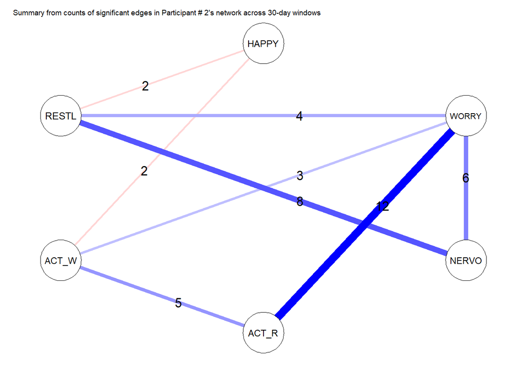

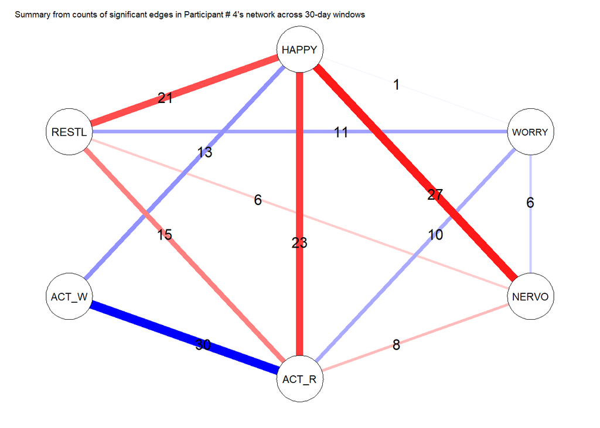

```r
for (pp_id in c(2,4)){

    temp_data <- dataset_imp[dataset_imp$Participant == pp_id,-c(1,9:13)]
    #matrix for negative associations
    negmat <- data.frame(matrix(ncol = 6, nrow = 6))
    x <- c("Happy", "Worrying", "Nervous", "Act_later_regret", "Act_without_thinking", "Restless")
    colnames(negmat) <- x
    rownames(negmat) <- x
    negmat[is.na(negmat)] <- 0
    #matrix for positive associations
    posmat <- data.frame(matrix(ncol = 6, nrow = 6))
    x <- c("Happy", "Worrying", "Nervous", "Act_later_regret", "Act_without_thinking", "Restless")
    colnames(posmat) <- x
    rownames(posmat) <- x
    posmat[is.na(posmat)] <- 0

  for (d in seq_len(30)){

    temp <- pcor(temp_data[temp_data$Time %in% d:(d+30),c("Happy", "Worrying","Nervous","Act_later_regret","Act_without_thinking","Restless")])

    temp_posmat <- ifelse(temp$p.value < 0.05 & temp$estimate > 0.199, 1, 0) # positive significant edges
    posmat <- posmat + temp_posmat

    temp_negmat <- ifelse(temp$p.value < 0.05 & temp$estimate < -0.199, 1, 0)# negative significant edges
    negmat <- negmat + temp_negmat

  }
    negmat[is.na(negmat)] <- 0
    posmat[is.na(posmat)] <- 0
    countsmatrix <- as.matrix(posmat)
    countsmatrix[upper.tri(countsmatrix)] <- negmat[upper.tri(negmat)]
    summaryplot <- qgraph(countsmatrix,
                          layout = "circle",
                          esize = 12,
                          arrows = F,
                          edge.labels = T,
                          edge.label.color = "black",
                          edge.label.bg = F,
                          edge.label.position = 0.6,
                          edge.label.cex = 1.2,
                          curveAll = F,
                          parallelEdge =T,
                          edge.color = as.matrix(colmat),
                          title = paste0("Summary from counts of significant edges in Participant # ",pp_id, "'s network across 30-day windows"),
                          title.cex = 0.6,
                          labels = c("HAPPY","WORRY","NERVO","ACT_R","ACT_W","RESTL"))
    summaryplot
}
```

Next we do this in a loop for all participants

```r
for (pp_id in unique(dataset_imp$Participant)){

    temp_data <- dataset_imp[dataset_imp$Participant == pp_id,-c(1,9:13)]
    #matrix for negative associations
    negmat <- data.frame(matrix(ncol = 6, nrow = 6))
    x <- c("Happy", "Worrying", "Nervous", "Act_later_regret", "Act_without_thinking", "Restless")
    colnames(negmat) <- x
    rownames(negmat) <- x
    negmat[is.na(negmat)] <- 0
    #matrix for negative associations
    posmat <- data.frame(matrix(ncol = 6, nrow = 6))
    x <- c("Happy", "Worrying", "Nervous", "Act_later_regret", "Act_without_thinking", "Restless")
    colnames(posmat) <- x
    rownames(posmat) <- x
    posmat[is.na(posmat)] <- 0

  for (d in seq_len(30)){

    temp <- pcor(temp_data[temp_data$Time %in% d:(d+30),c("Happy", "Worrying","Nervous","Act_later_regret","Act_without_thinking","Restless")])

    temp_posmat <- ifelse(temp$p.value < 0.05 & temp$estimate > 0.199, 1, 0)
    posmat <- posmat + temp_posmat

    temp_negmat <- ifelse(temp$p.value < 0.05 & temp$estimate < -0.199, 1, 0)
    negmat <- negmat + temp_negmat

  }
    negmat[is.na(negmat)] <- 0
    posmat[is.na(posmat)] <- 0
    countsmatrix <- as.matrix(posmat)
    countsmatrix[upper.tri(countsmatrix)] <- negmat[upper.tri(negmat)] #combine both negative and positive diagonals in one assymetric matrix
    jpeg(paste0("wp_network_change_",pp_id,".jpeg"), units = 'in', width = 5, height = 5, res = 600)
    summaryplot <- qgraph(countsmatrix,
                          layout = "circle",
                          esize = 12,
                          arrows = F,
                          edge.labels = T,
                          edge.label.color = "black",
                          edge.label.bg = F,
                          edge.label.position = 0.6,
                          edge.label.cex = 1.2,
                          curveAll = F,
                          parallelEdge =T,
                          edge.color = as.matrix(colmat),
                          title = paste0("Summary from counts of significant edges in Participant # ",pp_id, "'s network across 30-day windows"),
                          title.cex = 0.6,
                          labels = c("HAPPY","WORRY","NERVO","ACT_R","ACT_W","RESTL"))
    dev.off()
}
```

# Idiographic network change

## Change-point analyses

For every participant we now asses if the structure of the network changed from one stable state to another. This would indicate meaningful change. Below a table is construed evaluating whether a change-point occurred in the correlation structure between overlapping 30-day windows beyond a statistical threshold evaluated at p<0.05

```r
df_changepoint <- data.frame(matrix(ncol = 2, nrow = 0))
for (pp_id in unique(dataset_imp$Participant)){
  temp_data <- dataset_imp[dataset_imp$Participant == pp_id,-c(1,8:13)]
  res <- kcpRS(data=temp_data,
               RS_fun=runCorr,
               RS_name="Correlation",
               wsize=30,
               nperm=1000,
               Kmax=3,
               alpha=.05,
               varTest=FALSE,
               ncpu=detectCores())
  df_changepoint <- rbind(df_changepoint, c(pp_id, ifelse(identical(res$changePoints, numeric(0)),"None",res$changePoints)))
}
x <- c("pp_id", "changepoint")
colnames(df_changepoint) <- x
kable(df_changepoint, caption = "Table 2. Results change-points analyses")
```

Table 2. Results change-points analyses

[output not shown]

Let’s see what this looks like for participant 28; the only one with a change-point.

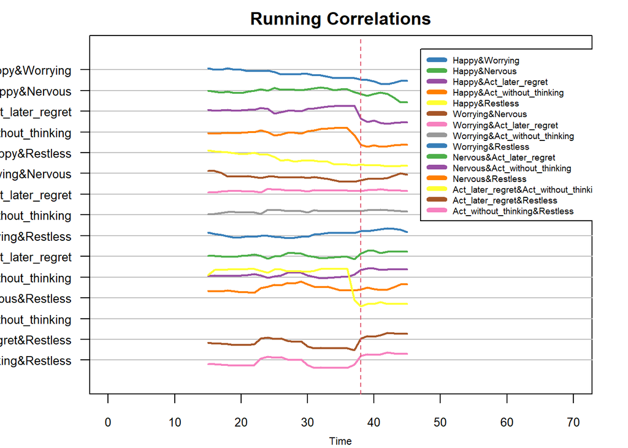

```r
plot(kcpRS(data=dataset_imp[dataset_imp$Participant == 28,-c(1,8:13)],
           RS_fun=runCorr,
           RS_name="Correlation",
           wsize=30,
           nperm=1000,
           Kmax=3,
           alpha=.05,
           varTest=FALSE,
           ncpu=detectCores()))
```

## Dynamic network videos

Thanks to Sacha Epskamp for sharing code from Wichers et al. (2016), which was a nice starting point for the following script

```r
Window <- 30

dataset_video <- dataset_imp[-which(dataset_imp$Participant == 6|dataset_imp$Participant == 32),]#Participant 6 and 32 were excluded for too much zero-variance within 30-day windows, which is why network videos cannot be estimated

# Loop through all participants
for (pp_id in unique(dataset_video$Participant)){

  temp_data <- dataset_video[dataset_video$Participant == pp_id,-c(1,9:13)]

  # Create list with partial correlation matrices per window
  pcorlist <- list()
  for (d in seq_len(30))
  {
    pcorlist[[d]] <-  pcor(temp_data[temp_data$Time %in% d:(d+Window),c("Happy", "Worrying","Nervous","Act_later_regret","Act_without_thinking","Restless")])$estimate
  }

  pcorlist <- rapply(pcorlist,function(x) ifelse(x==0.00000000,0.00000001,x), how = "replace") # will be pruned

  # Create list with network visualizations from partial correlation matrices per window
  GraphList <- qgraph.animate(pcorlist, graph = "pcor",  color = rainbow(6), vTrans = 150,  minimum = 0.2, layout="spring", labels = c("HAPPY","WORRY","NERVO","ACT_R","ACT_W","RESTL"),
                            theme = "colorblind", plotGraphs = F, smooth = TRUE, mar = c(5,5,5,5),edge.label = F,
                            title = paste("Dynamic network video of participant ", pp_id, sep = ""), title.cex = 3)

  ani.options(ffmpeg = "C:\\Users\\daanh\\OneDrive\\Documenten\\Pluryn\\ffmpeg-4.2.2-win64-static\\bin\\ffmpeg.exe")

  # Create video
  saveVideo({
    layout(matrix(c(
    0,2,2,2,2,1,1,1,1,1,1,
    0,3,3,3,3,1,1,1,1,1,1,
    0,4,4,4,4,1,1,1,1,1,1,
    0,5,5,5,5,1,1,1,1,1,1,
    0,6,6,6,6,1,1,1,1,1,1,
    0,7,7,7,7,1,1,1,1,1,1),6,11,byrow=TRUE))

    for (d in seq_along(GraphList))
    {
      if (d < length(GraphList))
      {
        smoothlist <- qgraph:::smoothAnimationList(GraphList[d:(d+1)], 5)
      } else smoothlist <- GraphList[d]

      for (p in seq_along(smoothlist))  {
          plot(smoothlist[[p]]) # This is the network, what follows are raw time-series plus window demarcations as vertical lines
          plot(temp_data$Time[temp_data$Time <= d+Window],  temp_data$Happy[temp_data$Time <= d+Window], type = 'b', bty = 'n', xlab = "", col = 'red', ylab = "Happy", xaxt = 'n', yaxt = 'n', xlim=c(1,nrow(temp_data)), ylim = range(0:4), cex.axis = 2, cex.lab = 2, cex = 2, lwd = 2)
          axis(1, at=seq(1,60,by=1), cex.axis = 2, cex.lab = 2, cex = 2, lwd = 1)
          axis(2, at=seq(0,4,by=1), cex.axis = 2, cex.lab = 2, cex = 2, lwd = 1)
          abline(v = d)
          abline(v = d+Window)
          plot(temp_data$Time[temp_data$Time <= d+Window],  temp_data$Worrying[temp_data$Time <= d+Window], type = 'b', bty = 'n', xlab = "",col = 'yellow',  ylab = "Worry", xaxt = 'n', yaxt = 'n', xlim=c(1,nrow(temp_data)), ylim = range(0:4), cex.axis = 2, cex.lab = 2, cex = 2, lwd = 2)
          axis(1, at=seq(1,60,by=1), cex.axis = 2, cex.lab = 2, cex = 2, lwd = 1)
          axis(2, at=seq(0,4,by=1), cex.axis = 2, cex.lab = 2, cex = 2, lwd = 1)
          abline(v = d)
          abline(v = d+Window)
          plot(temp_data$Time[temp_data$Time <= d+Window],  temp_data$Nervous[temp_data$Time <= d+Window], type = 'b', bty = 'n', xlab = "", col = 'green', ylab = "Nervous", xaxt = 'n', yaxt = 'n', xlim=c(1,nrow(temp_data)), ylim = range(0:4), cex.axis = 2, cex.lab = 2, cex = 2, lwd = 2)
          axis(1, at=seq(1,60,by=1), cex.axis = 2, cex.lab = 2, cex = 2, lwd = 1)
          axis(2, at=seq(0,4,by=1), cex.axis = 2, cex.lab = 2, cex = 2, lwd = 1)
          abline(v = d)
          abline(v = d+Window)
          plot(temp_data$Time[temp_data$Time <= d+Window],  temp_data$Act_later_regret[temp_data$Time <= d+Window], type = 'b', bty = 'n', col = 'cyan', xlab = "", ylab = "Act_later_regret", xaxt = 'n', yaxt = 'n', xlim=c(1,nrow(temp_data)), ylim = range(0:4), cex.axis = 2, cex.lab = 2, cex = 2, lwd = 2)
          axis(1, at=seq(1,60,by=1), cex.axis = 2, cex.lab = 2, cex = 2, lwd = 1)
          axis(2, at=seq(0,4,by=1), cex.axis = 2, cex.lab = 2, cex = 2, lwd = 1)
          abline(v = d)
          abline(v = d+Window)
          plot(temp_data$Time[temp_data$Time <= d+Window],  temp_data$Act_without_thinking[temp_data$Time <= d+Window], type = 'b', bty = 'n', col = 'blue', xlab = "", ylab = "Act_without_thinking", xaxt = 'n', yaxt = 'n', xlim=c(1,nrow(temp_data)), ylim = range(0:4), cex.axis = 2, cex.lab = 2, cex = 2, lwd = 2)
          axis(1, at=seq(1,60,by=1), cex.axis = 2, cex.lab = 2, cex = 2, lwd = 1)
          axis(2, at=seq(0,4,by=1), cex.axis = 2, cex.lab = 2, cex = 2, lwd = 1)
          abline(v = d)
          abline(v = d+Window)
          plot(temp_data$Time[temp_data$Time <= d+Window],  temp_data$Restless[temp_data$Time <= d+Window], type = 'b', bty = 'n', xlab = "", col = 'magenta', ylab = "Restless", xaxt = 'n', yaxt = 'n', xlim=c(1,nrow(temp_data)), ylim = range(0:4), cex.axis = 2, cex.lab = 2, cex = 2, lwd = 2)
          axis(1, at=seq(1,60,by=1), cex.axis = 2, cex.lab = 2, cex = 2, lwd = 1)
          axis(2, at=seq(0,4,by=1), cex.axis = 2, cex.lab = 2, cex = 2, lwd = 1)
          abline(v = d)
          abline(v = d+Window)
      }
    } # lastly, save videos in folder as .avi
  }, ani.width = 1900, ani.height = 950, video.name = paste0("Dynamic_Networks_Video_Participant_",pp_id,".avi"), interval = 0.05, other.opts = "-vb 20M -vcodec mpeg4", clean = TRUE, outdir = "C:/Users/Daan/Videos/RVideos/")
}
```